# Spatial AutoCorrelation

## Fig 1

```r
####### Provided code
local_moran_queen <- localmoran(
x = NC_UTM$MNEM2000,
  listw = queen_nb_w,
  zero.policy = TRUE,
  alternative = "two.sided"
)
head(local_moran_queen)
```

```
           Ii         E.Ii     Var.Ii       Z.Ii Pr(z != E(Ii))
1 0.224968418 -0.002784784 0.09067850 0.75633175      0.4494503
2 0.006921914 -0.005258719 0.17081028 0.02947222      0.9764880
3 0.073576987 -0.001178770 0.02258649 0.49741664      0.6188953
4 0.660771648 -0.006634965 0.32618436 1.16858131      0.2425724
5 0.386756847 -0.004588473 0.11068999 1.17626713      0.2394881
6 0.448120266 -0.004260557 0.13852749 1.21544748      0.2241955
```

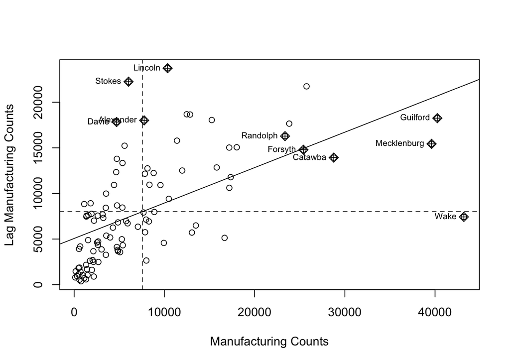

```r
moran.plot(
  x = NC_UTM$MNEM2000,
  listw = queen_nb_w,
  labels = NC_UTM$NAME,
  xlab = "Manufacturing Counts",
  ylab = "Lag Manufacturing Counts"
)
```

## Fig 2

```r
library(tidyverse)
# This pulls out the quadrants from the results and assigns it to a vector
quadr <- attr(local_moran_queen, "quadr")[, 2]
NC_localmoran <- NC_UTM
NC_localmoran$Quadrant <- quadr
# The 5th column represents the p-value
NC_localmoran$p.value <- local_moran_queen[, 5]
sig_level <- 0.5
NC_localmoran <- NC_localmoran %>%
  mutate(
    Quadrant_Sig = if_else(
      p.value <= sig_level,
      true = as.character(Quadrant),
      false = "Insignificant"
    ) %>%
      as.factor()
)

lm_pal <-
c(
    "High-High" = "red",
    "High-Low" = "#FF000080",
    "Insignificant" = "gray90",
    "Low-High" = "#0000FF80",
    "Low-Low" = "blue"
)
tm_shape(NC_localmoran) +
  tm_polygons(
    col = "Quadrant_Sig",
    palette = lm_pal,
    border.col = "black") +
  tm_layout(
  main.title = paste0("LISA Cluster at Alpha = ", sig_level)
)
```

[figure not shown]

# LISA at various Alpha

**Adopt the code above to provide LISA maps for the MNEM1990 variable at an alpha of 0.1, 0.05, and 0.01 using the Queen’s case W. Provide a brief explanation of your findings about any local spatial autocorrelation at these more restrictive values of alpha.**

```r
# Provide code: Setting Queen's Case
local_moran_queen <- localmoran(
x = NC_UTM$MNEM1990,
  listw = queen_nb_w,
  zero.policy = TRUE,
  alternative = "two.sided"
)

quadr <- attr(local_moran_queen, "quadr")[, 2]

# Creating function to run local morans I (LISA) at various significance levels

dans_LISA <-  function(x) {NC_localmoran <- NC_UTM
NC_localmoran$Quadrant <- quadr
# The 5th column represents the p-value
NC_localmoran$p.value <- local_moran_queen[, 5]
sig_level <- x
NC_localmoran <- NC_localmoran %>%
  mutate(
    Quadrant_Sig = if_else(
      p.value <= sig_level,
      true = as.character(Quadrant),
      false = "Insignificant"
    ) %>%
      as.factor()
  )

return(NC_localmoran)
}

a <- list(0.1, .05, .01)


# this outputs a list of all tables for each significance level
lisa_output <- lapply(a, dans_LISA)
```

```r
# Filters LISA output tables to only return County Name and Quadrant_Sig

LISA_table <- function(lisa_output) {
  table <- lisa_output %>%
  filter(Quadrant_Sig !=  "Insignificant") %>%
  group_by(Quadrant_Sig) %>%
  select(County = NAME,
         Quadrant_Sig) %>%
    st_drop_geometry()
  return(table)
}

# A list of resulting tables
tables <- lapply(lisa_output, LISA_table)
```

## Fig 1

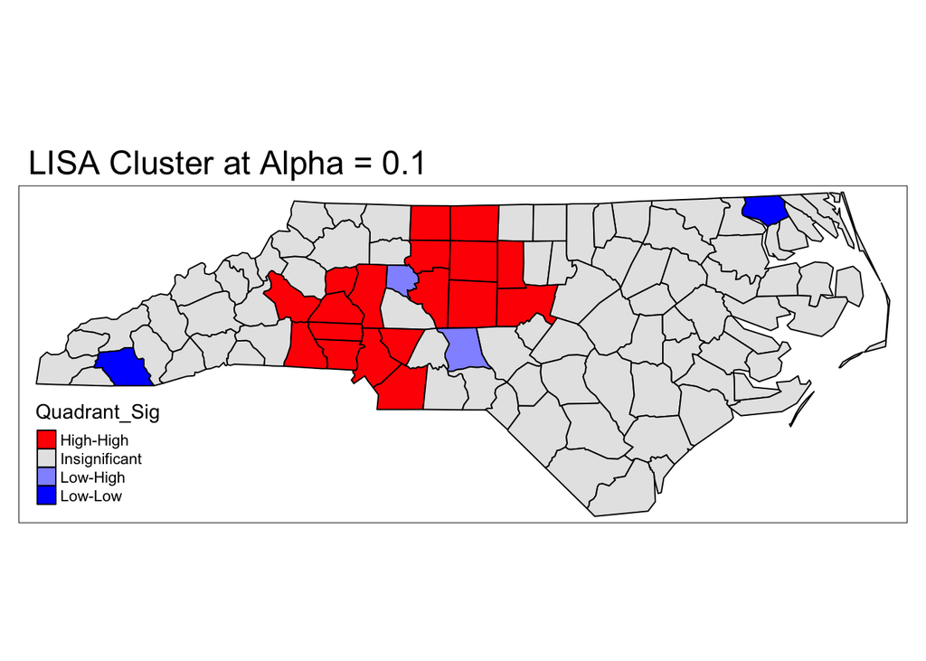

```r
# a function to plot
dans_plot_LISA <- function(x, sig_level) {

  plot <- tm_shape(x) +
  tm_polygons(
    col = "Quadrant_Sig",
    palette = lm_pal,
    border.col = "black") +
  tm_layout(
  main.title = paste0("LISA Cluster at Alpha = ", sig_level)
)
  return(plot)
}

plots <- mapply(dans_plot_LISA, x = lisa_output, sig_level = a, SIMPLIFY = FALSE)

# Despite becoming function obsessed I couldnt figure out how to get my read_out to order correctly with a function/lapply.. but boy did I try. Unsure as to why the group_by() effect for Quadrant_Sig is no longer displaying after using lapply(), run individually things are ordered properly but w/e.
plots[1]
```

```r
tables[1]
```

```
[[1]]
# A tibble: 22 × 2
# Groups:   Quadrant_Sig [3]
   County     Quadrant_Sig
 * <chr>      <fct>
 1 Gates      Low-Low
 2 Stokes     High-High
 3 Rockingham High-High
 4 Forsyth    High-High
 5 Guilford   High-High
 6 Alamance   High-High
 7 Iredell    High-High
 8 Davie      Low-High
 9 Alexander  High-High
10 Davidson   High-High
# ℹ 12 more rows
```

## Fig 2

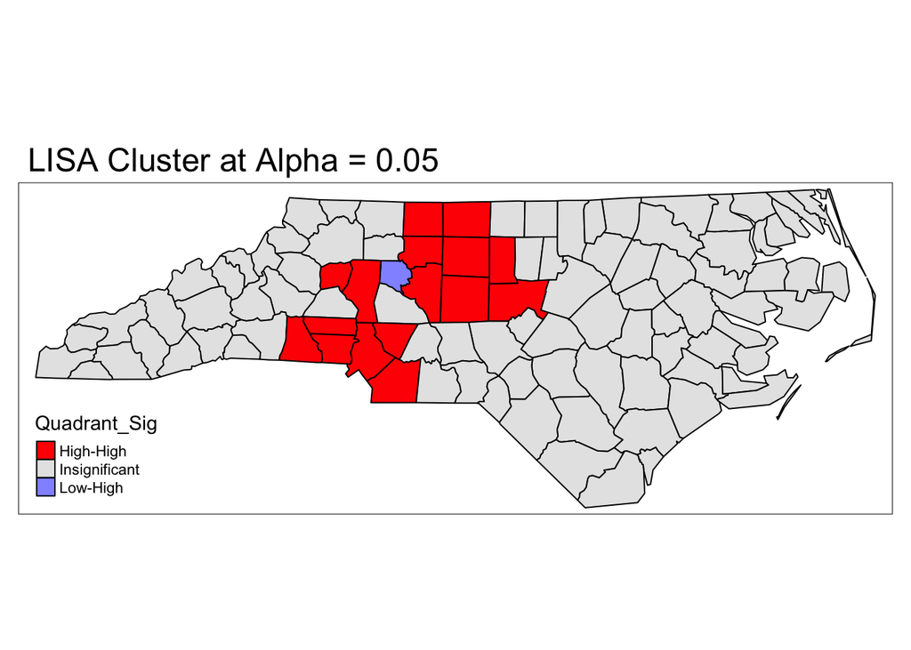

```r
plots[2]
```

```r
tables[2]
```

```
[[1]]
# A tibble: 17 × 2
# Groups:   Quadrant_Sig [2]
   County      Quadrant_Sig
 * <chr>       <fct>
 1 Stokes      High-High
 2 Rockingham  High-High
 3 Forsyth     High-High
 4 Guilford    High-High
 5 Alamance    High-High
 6 Iredell     High-High
 7 Davie       Low-High
 8 Alexander   High-High
 9 Davidson    High-High
10 Randolph    High-High
11 Chatham     High-High
12 Cleveland   High-High
13 Lincoln     High-High
14 Mecklenburg High-High
15 Cabarrus    High-High
16 Gaston      High-High
17 Union       High-High
```

## Fig 3

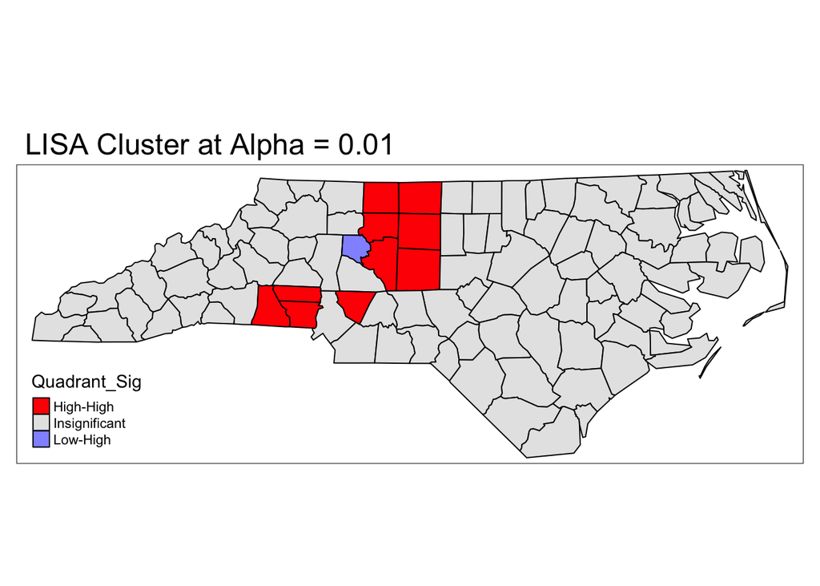

```r
plots[3]
```

```r
tables[3]
```

```
[[1]]
# A tibble: 11 × 2
# Groups:   Quadrant_Sig [2]
   County     Quadrant_Sig
 * <chr>      <fct>
 1 Stokes     High-High
 2 Rockingham High-High
 3 Forsyth    High-High
 4 Guilford   High-High
 5 Davie      Low-High
 6 Davidson   High-High
 7 Randolph   High-High
 8 Cleveland  High-High
 9 Lincoln    High-High
10 Cabarrus   High-High
11 Gaston     High-High
```

It seems like there are two sort’ve primary High-High clusters in the western Piedmont as well as a couple Low-Low and Low-High counties depending on the significance level.